# Assignment 8 - Iteration

Author

Madhuparna Deb

# 1 Goal of this assignment

The goal of this assignment is for you to **apply different iteration concepts** learned in class to a new data set.

In specific, you will be asked to:  
- create a function to automate plot creation  
- apply this function to different parts of a dataset through the use of the map function.

# 2 Instructions

- Move this script into the `code` subfolder of your `08_iteration` project
- On this script, fill your name under the `title` section of the YAML
- On this script, you will be asked to:
  - Import the raw soybeans data set used in the `02_wrangling` project
  - Create a function to automate the creation of boxplots
  - Create a map workflow to apply your function to different locations in the data set

# 3 Code

Hereafter is where you will develop your code.  
Remember to load any necessary packages and the data.

## 3.1 Q1 - Create a function

Here, you are asked to create a function.  
The goal of this function is to create a boxplot of K leaf concentration as a function of K rates.  
Name the function `myplot`.  
The function inputs are:  
- df: the data set containing the columns needed for plotting  
- x: the column name inside df to be plotted on the x axis  
- y: the column name inside df to be plotted on the y axis

Once you create the function, make sure it works by applying it to one of the locations where K leaf concentration was collected.

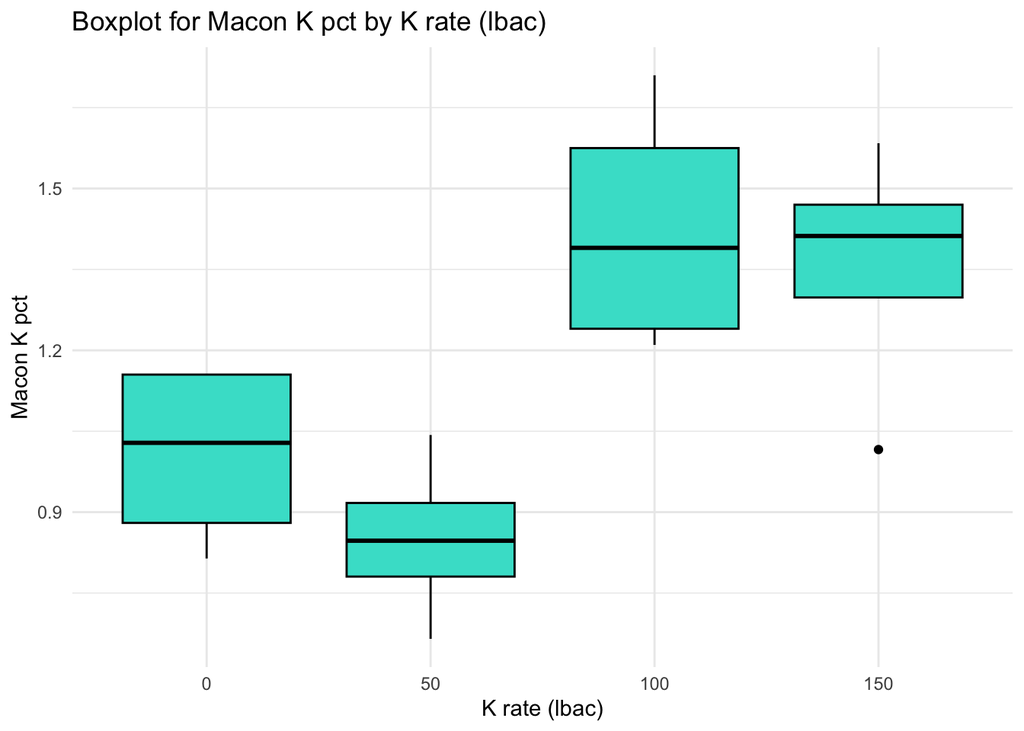

```r
#install.packages("dplyr")
install.packages("readxl", repos = "https://cran.rstudio.com/")
install.packages("purrr",  repos = "https://cran.rstudio.com/")
install.packages("ggplot2", repos = "https://cran.rstudio.com/")
library(readxl)
#library(dplyr)
library(ggplot2)
library(purrr)


# Function to create boxplot
soyk <- read_xlsx("../01_soybeans.xlsx")


# Create the myplot function
myplot <- function(df, x, y) {
  ggplot(df, aes(x = as.factor(.data[[x]]), y = .data[[y]])) +
    geom_boxplot(fill = "turquoise", color = "black") +
    labs(x = x, y = y, title = paste("Boxplot for", y, "by", x)) +
    theme_minimal()
}

# Apply the function to create a boxplot for 'Midville K pct' as a function of 'K rate (lbac)'
myplot(soyk, 'K rate (lbac)', 'Macon K pct')
```

## 3.2 Q2 - Iterate over locations

On the step above you created a function to create boxplot for one location (one column in your original data set).

Now, you are asked to apply this function to each location in the data set.  
For that, use one of the functions in the `map` family from the purr package.  
When making your plots, make sure to add a title to represent which location is represented in each plot.

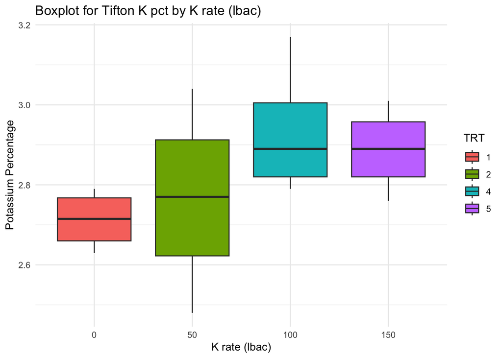

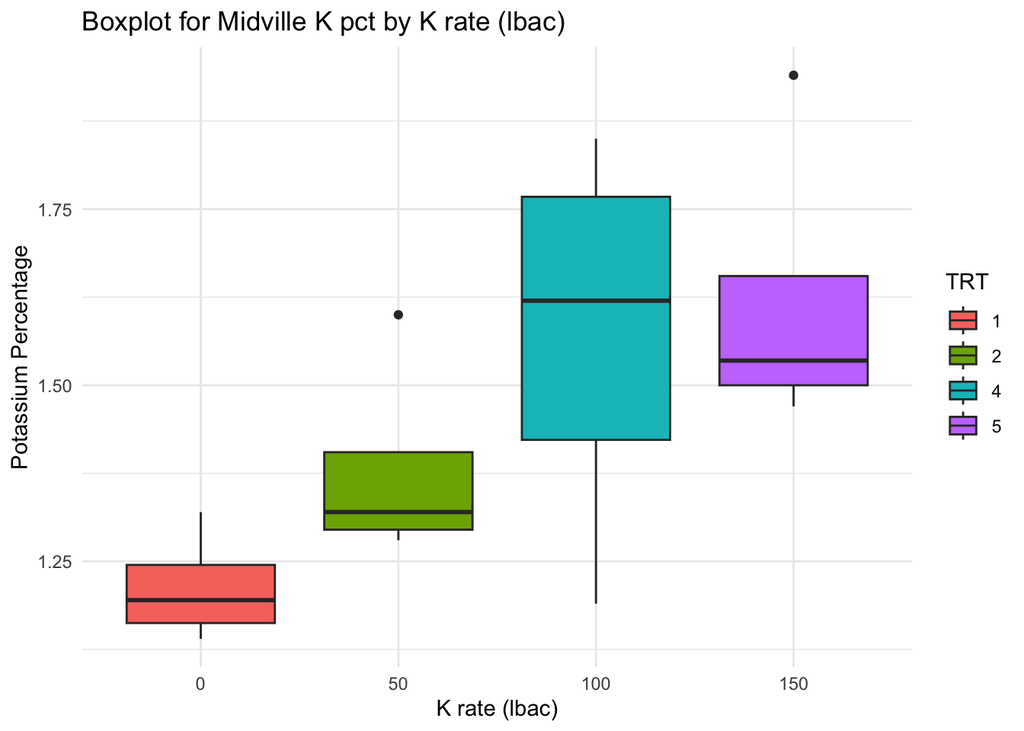

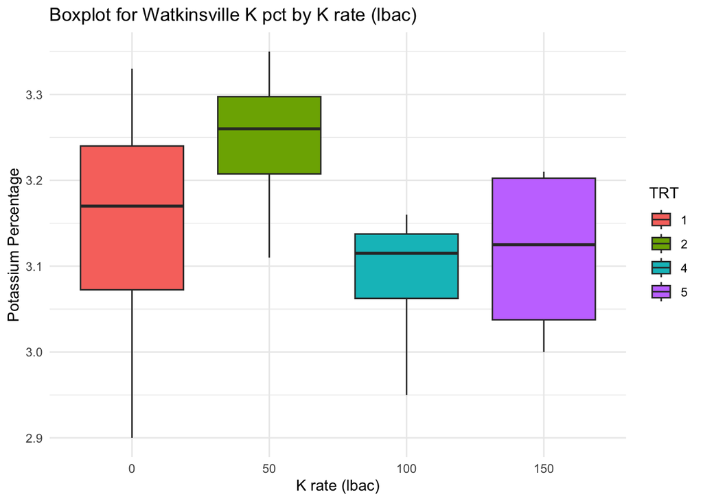

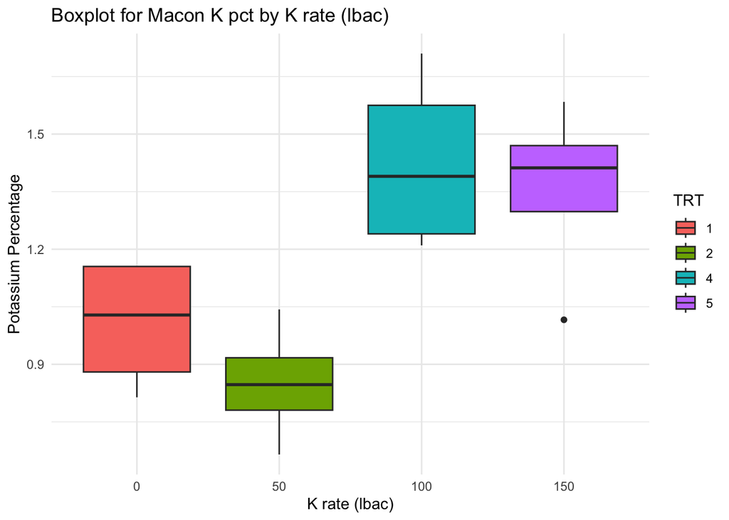

```r
data <- soyk
plot_location <- function(location) {
  ggplot(data, aes(x = as.factor(`K rate (lbac)`), y = .data[[location]], fill = as.factor(TRT))) +
    geom_boxplot() +
    labs(title = paste("Boxplot for", location, "by K rate (lbac)"),
         x = "K rate (lbac)",
         y = "Potassium Percentage",
         fill = "TRT") +
    theme_minimal()
}


data_locations <- c("Tifton K pct", "Midville K pct", "Watkinsville K pct", "Macon K pct")


plots <- map(data_locations, plot_location)


print(plots)
```

# 4 Submitting your work

Once you have developed all the code and answers, make sure to Render this quarto file.

**Notes on rendering**:

- Make sure to render your work and inspect how the final html look like.
- If it does not look professional for whatever reason, then fix the issue, re-render it, recheck.
- Only send me your work once your html file looks professional.
  - **DO NOT** delete the file’s heading levels (# and ##). They set up the proper heading 1 and 2 levels, and I use them to guide my grading.
  - If a given chunk is also outputting warnings or messages, inhibit this behavior by changing the chunk options `message` and `warning` to `FALSE` (I’ll demo this in a moment).
  - If, after rendered, 2 lines of text are connected and you wish to “break line” between them, add 2 extra spaces after the first one (I’lld demo this in a moment).

After rendering, an .html file will be created on your `code` folder.

Rename this file to `Assignment-08-iteration-LASTNAME.html`.

For ex., mine would be `Assignment-08-iteration-Bastos.html`.

Submit your work by uploading the **html** file to **eLC Assignment #8 - Iteration** by Mar 18 11:59 pm.